# Entrega Final

## Semana Tec. El arte de la analítica

#### Jatzive Adriana Pérez Solís | A01701715

#### Cutberto Arizabalo Nava | A01411431

#### Diego Carrillo Torres | A01612532

# Entregable 2: Importar datos e identificar variables

## Paso 1: importar datos

```python
import pandas as pd
data=pd.read_csv('MXvideosUTF8.csv')
```

```python
data.head()
```

|  | video_id | trending_date | title | channel_title | category_id | publish_time | tags | views | likes | dislikes | comment_count | thumbnail_link | comments_disabled | ratings_disabled | video_error_or_removed | description |
| --- | --- | --- | --- | --- | --- | --- | --- | --- | --- | --- | --- | --- | --- | --- | --- | --- |
| 0 | SbOwzAl9ZfQ | 17.14.11 | Capítulo 12 \| MasterChef 2017 | MasterChef 2017 | 24 | 2017-11-13T06:06:22.000Z | MasterChef Junior 2017\|"TV Azteca"\|"recetas"\|"... | 310130 | 4182 | 361 | 1836 | https://i.ytimg.com/vi/SbOwzAl9ZfQ/default.jpg | False | False | False | Disfruta la presencia del Chef Torreblanca en ... |
| 1 | klOV6Xh-DnI | 17.14.11 | ALEXA EX-INTEGRANTE DEL GRUPO TIMBIRICHE RENUN... | Micky Contreras Martinez | 22 | 2017-11-13T05:11:58.000Z | La Voz Mexico 7 | 104972 | 271 | 174 | 369 | https://i.ytimg.com/vi/klOV6Xh-DnI/default.jpg | False | False | False | ALEXA EX-INTEGRANTE DEL GRUPO TIMBIRICHE RENUN... |
| 2 | 6L2ZF7Qzsbk | 17.14.11 | LOUIS CKAGÓ - EL PULSO DE LA REPÚBLICA | El Pulso De La República | 25 | 2017-11-13T17:00:02.000Z | Chumel Torres\|"El Pulso de la Republica"\|"noti... | 136064 | 10105 | 266 | 607 | https://i.ytimg.com/vi/6L2ZF7Qzsbk/default.jpg | False | False | False | La canción del principio se llama “Este esp... |
| 3 | hcY52MFWMDM | 17.14.11 | Sismo de 6.7 sacude Costa Rica 12 Noviembre 2017 | Casanare | 25 | 2017-11-13T03:47:10.000Z | temblor\|"costa rica"\|"sismo en costa rica" | 96153 | 378 | 171 | 208 | https://i.ytimg.com/vi/hcY52MFWMDM/default.jpg | False | False | False | El video es de un Walmart en el pais centroame... |
| 4 | _OXDcGPVAa4 | 17.14.11 | DOG HACKS \| MUSAS LESSLIE LOS POLINESIOS | Musas | 26 | 2017-11-13T19:17:48.000Z | MUSAS\|"lesslie"\|"karen"\|"hacks"\|"perros"\|"dogs... | 499965 | 57781 | 681 | 7428 | https://i.ytimg.com/vi/_OXDcGPVAa4/default.jpg | False | False | False | MI HERMANO NARRA MI RUTINA DE MAQUILLAJE\nhttp... |

## Paso 2: identificación de variables

```python
data.columns.values
```

```
array(['video_id', 'trending_date', 'title', 'channel_title',
       'category_id', 'publish_time', 'tags', 'views', 'likes',
       'dislikes', 'comment_count', 'thumbnail_link', 'comments_disabled',
       'ratings_disabled', 'video_error_or_removed', 'description'],
      dtype=object)
```

```python
i = 0
for columns in data:
    print(data.columns[i])
    i+=1
```

```
video_id
trending_date
title
channel_title
category_id
publish_time
tags
views
likes
dislikes
comment_count
thumbnail_link
comments_disabled
ratings_disabled
video_error_or_removed
description
```

```python
data.info
```

```
<bound method DataFrame.info of           video_id trending_date  \
0      SbOwzAl9ZfQ      17.14.11
1      klOV6Xh-DnI      17.14.11
2      6L2ZF7Qzsbk      17.14.11
3      hcY52MFWMDM      17.14.11
4      _OXDcGPVAa4      17.14.11
...            ...           ...
40446  r63VBOagGAo      18.14.06
40447  i7r_kMbyngk      18.14.06
40448  _jnwjdMe3Zo      18.14.06
40449  pAH9omNAWA4      18.14.06
40450  dj5Z4jTE3-c      18.14.06

                                                   title  \
0                         CapÃtulo 12 | MasterChef 2017
```

[output cut: 90 more lines]

## Descripción de las variables

```python
data.describe()
```

|  | category_id | views | likes | dislikes | comment_count |
| --- | --- | --- | --- | --- | --- |
| count | 40451.000000 | 4.045100e+04 | 4.045100e+04 | 4.045100e+04 | 40451.000000 |
| mean | 21.003140 | 3.423820e+05 | 1.586184e+04 | 7.471604e+02 | 2039.660008 |
| std | 5.878995 | 1.714691e+06 | 8.108987e+04 | 1.095358e+04 | 13938.031797 |
| min | 1.000000 | 1.570000e+02 | 0.000000e+00 | 0.000000e+00 | 0.000000 |
| 25% | 20.000000 | 1.681300e+04 | 2.990000e+02 | 1.700000e+01 | 42.000000 |
| 50% | 24.000000 | 5.697300e+04 | 1.246000e+03 | 6.300000e+01 | 196.000000 |
| 75% | 24.000000 | 2.068940e+05 | 7.226000e+03 | 2.670000e+02 | 885.000000 |
| max | 43.000000 | 1.009124e+08 | 4.470923e+06 | 1.353667e+06 | 905925.000000 |

## Significado de las categorías en la base de datos

## From youtube upload page

#### 2 - Cars & Vehicles

#### 23 - Comedy

#### 27 - Education

#### 24 - Entertainment

#### 1 - Film & Animation

#### 20 - Gaming

#### 26 - How-to & Style

#### 10 - Music

#### 25 - News & Politics

#### 29 - Non-profits & Activism

#### 22 - People & Blogs

#### 15 - Pets & Animals

#### 28 - Science & Technology

#### 17 - Sport

#### 19 - Travel & Events

# Entregable 3 Graficación de datos

# Paso 1

## Importar los datos

Aquí se incluyen varios archivos que preparamos para la actividad. Todos estos son versiones filtradas del documento original, con el objetivo de agilizar el reconocimiento de los datos por los algoritmos de seaborn

```python
import pandas as pd
cutdown2 = pd.read_csv('MXVideos3.csv')
randvidyear = pd.read_csv('randvidyear.csv')
yearmonth = pd.read_csv('year-month-stats.csv')
heatprep = pd.read_csv('heatprep.csv', usecols=[1,2,3,4,5,6,7,8,9,10,11,12])
```

# Paso 2

## Realiza el análisis de las variables usando diagramas de cajas y bigotes, histogramas y mapas de calor.

Importar librerías

```python
import seaborn as sb
import numpy as np
import matplotlib.pyplot as plt
```

# Diagramas de caja y bigote

Primero compararemos la cantidad de likes obtenidas en cada categoría, apoyándonos de diagramas de cajas

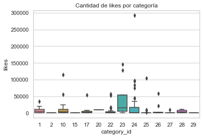

```python
sb.set_theme(style = "whitegrid")
sbdata = cutdown2

ax = sb.boxplot (x="category_id", y= "likes", data = sbdata)
plt.title('Cantidad de likes por categoría')
```

Realizamos un acercamiento a la gráfica

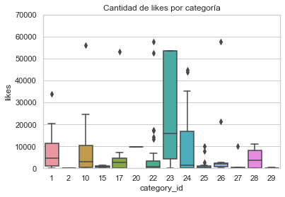

```python
ax = sb.boxplot (x="category_id", y= "likes", data = sbdata)

ax.set(ylim=(0, 70000))
plt.title('Cantidad de likes por categoría')
```

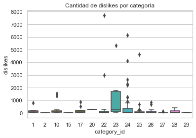

```python
ax = sb.boxplot (x="category_id", y= "dislikes", data = sbdata)
plt.title('Cantidad de dislikes por categoría')
```

Realizamos un acercamiento a la gráfica para apreciar mejor los datos

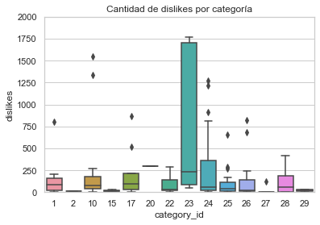

```python
ax = sb.boxplot (x="category_id", y= "dislikes", data = sbdata)

ax.set(ylim=(0, 2000))
plt.title('Cantidad de dislikes por categoría')
```

Utilizando la base de datos yearmonth, la cual contiene las estadísticas de un video aleatorio por mes,compararemos estos datos

Cabe mencionar que para que los datos sean más significativos sería necesario calcular el promedio por año, sin embargo debido al tamaño de la base de datos original (+40,000 registros) la complejidad de catalogar manualmente cada video por mes y año para después sacar promedio queda fuera del alcance.

La primera comparación es para mostrar la cantidad de vistas obtenidas por los videos en cada año

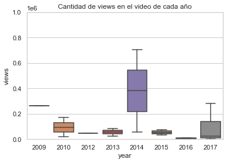

```python
ax = sb.boxplot(x="year", y= "views", data = yearmonth)

ax.set(ylim=(0, 1000000))

plt.title('Cantidad de views en el video de cada año')
```

A continuación realizamos esta misma comparación pero basados en la cantidad de likes

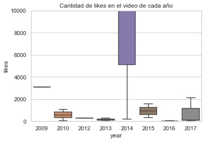

```python
ax = sb.boxplot(x="year", y= "likes", data = yearmonth)

ax.set(ylim=(0, 10000))
plt.title('Cantidad de likes en el video de cada año')
```

# Histogramas

```
array([[<AxesSubplot:title={'center':'category_id'}>,
        <AxesSubplot:title={'center':'views'}>],
       [<AxesSubplot:title={'center':'likes'}>,
        <AxesSubplot:title={'center':'dislikes'}>],
       [<AxesSubplot:title={'center':'comment_count'}>,
        <AxesSubplot:title={'center':'year'}>]], dtype=object)
```

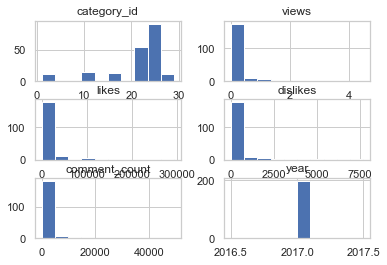

```python
cutdown2.drop([0,1]).hist()
```

# Histogramas

En este histograma se compara la cantidad de videos que reciben n cantidad de likes Podemos observar que la gran mayoría de videos recibe una baja cantidad de likes, por debajo de los 50,000

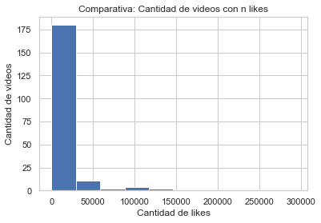

```python
cutdown2.likes.hist()
plt.title('Comparativa: Cantidad de videos con n likes')
plt.ylabel('Cantidad de videos')
plt.xlabel('Cantidad de likes')
```

Lo mismo sucede con la cantidad de dislikes como se puede observar a continuación

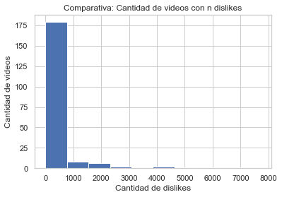

```python
cutdown2.dislikes.hist()
plt.title('Comparativa: Cantidad de videos con n dislikes')
plt.ylabel('Cantidad de videos')
plt.xlabel('Cantidad de dislikes')
```

# Mapas de calor

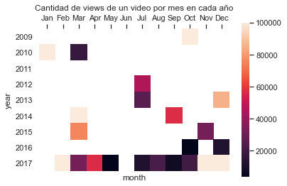

```python
xticks_labels = ['Jan', 'Feb', 'Mar', 'Apr', 'May', 'Jun',
                'Jul', 'Aug', 'Sep', 'Oct', 'Nov', 'Dec']
yticks_labels = ['2009', '2010', '2011', '2012', '2013',
                 '2014','2015', '2016', '2017']

ax = sb.heatmap(heatprep, vmax=100000, square = True, yticklabels=yticks_labels, xticklabels= xticks_labels)
plt.title('Cantidad de views de un video por mes en cada año')
plt.ylabel('year')
plt.xlabel('month')
ax.xaxis.tick_top()

plt.show()
```

# Entregable 4

## Procesamiento de datos mediante K-means

```python
import pandas as pd
import numpy as np
import seaborn as sb
import matplotlib.pyplot as plt
import sklearn
from sklearn.cluster import KMeans
from mpl_toolkits.mplot3d import Axes3D
from sklearn.preprocessing import scale
import sklearn.metrics as sm
from sklearn import datasets
from sklearn.metrics import confusion_matrix, classification_report
```

```python
yearmonth = pd.read_csv('year-month-stats.csv')
```

## Construcción del modelo

```python
X = scale(yearmonth)
y = pd.DataFrame(yearmonth.month)

X[0:10,]
```

[output not shown]

```python
clustering = KMeans(n_clusters = 3, random_state = 5)
clustering.fit(X)
```

```
KMeans(n_clusters=3, random_state=5)
```

## Salida del modelo

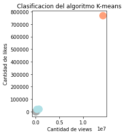

```python
relabel = np.choose (clustering.labels_,[2,0,1]).astype(np.int64)
color_theme = np.array(['darkgray', 'lightsalmon', 'powderblue'])
plt.subplot(1,2,1)
plt.scatter(x = yearmonth.views, y=yearmonth.likes, c=color_theme[clustering.labels_], s=200)
plt.title("Clasificacion del algoritmo K-means")
plt.xlabel("Cantidad de views")
plt.ylabel("Cantidad de likes")

#plt.subplot(1,2,2)
#plt.scatter(x=iris_df.Petal_Length, y=iris_df.Petal_Width, c=color_theme[clustering.labels_], s=50)
#plt.title("clasificacion algorimo kmeans")
```

```python
print (classification_report(y,clustering.labels_))
```

```
              precision    recall  f1-score   support

           0       0.00      0.00      0.00         0
           1       0.00      0.00      0.00         1
           2       0.07      1.00      0.13         1
           3       0.00      0.00      0.00         5
           4       0.00      0.00      0.00         1
           5       0.00      0.00      0.00         1
           7       0.00      0.00      0.00         3
           8       0.00      0.00      0.00         1
           9       0.00      0.00      0.00         2
          10       0.00      0.00      0.00         3
          11       0.00      0.00      0.00         2
          12       0.00      0.00      0.00         3

    accuracy                           0.04        23
   macro avg       0.01      0.08      0.01        23
weighted avg       0.00      0.04      0.01        23
```

## Interpretación

Debido a la forma en la que está estructurada la base de datos y al contenido de la misma, resultó imposible obtener una muestra de un video para cada mes de cada año, es por esto que la precisión del modelo se muestra tan baja, ya que se tiene un máximo de 5 muestras por mes. Sin embargo, en las gráficas nos es posible observar la forma en que se relaciona directamente la cantidad de views a la cantidad de likes